# DES_part4_03694565

## 4.3 Simulation Study III

```python
%matplotlib inline
from pylab import rcParams
rcParams['figure.figsize'] = (16,12)
```

```python
import part4_simstudy
```

```python
part4_simstudy.task_4_2_1()
```

```
Auro correlation sequence 1 for lag 0 = 0.9998
Auro correlation sequence 1 for lag 1 = -0.9998
Auro correlation sequence 1 for lag 2 = 0.9998
Auro correlation sequence 1 for lag 3 = -0.9998
Auro correlation sequence 1 for lag 4 = 0.9998
Auro correlation sequence 2 for lag 0 = 0.9998
Auro correlation sequence 2 for lag 1 = -0.9998
Auro correlation sequence 2 for lag 2 = 0.9998
Auro correlation sequence 2 for lag 3 = -0.9998
Auro correlation sequence 2 for lag 4 = 0.9998
```

```python
part4_simstudy.task_4_3_1()
```

```
RHO = 0.01
Correlation between IAT and waiting time of a packet = -0.06991131063921328
Correlation between IAT and serving time of a packet = -0.004454984177127434
Correlation between IAT and system time (waiting time + serving time) of a packet = -0.0130056118135687
Correlation between serving time and system time of a packet = 0.9923380710470904
Lag = 0 Auto-correlation of waiting time with lags ranging from 1 to 20 = 0.9999005964214714
Lag = 1 Auto-correlation of waiting time with lags ranging from 1 to 20 = -0.004862669205893557
Lag = 2 Auto-correlation of waiting time with lags ranging from 1 to 20 = -0.004429163356198464
Lag = 3 Auto-correlation of waiting time with lags ranging from 1 to 20 = -0.0034008097452160307
Lag = 4 Auto-correlation of waiting time with lags ranging from 1 to 20 = -0.004862669205893557
Lag = 5 Auto-correlation of waiting time with lags ranging from 1 to 20 = -0.0046954987869866445
Lag = 6 Auto-correlation of waiting time with lags ranging from 1 to 20 = -0.004862669205893558
Lag = 7 Auto-correlation of waiting time with lags ranging from 1 to 20 = -0.0028499708207052393
Lag = 8 Auto-correlation of waiting time with lags ranging from 1 to 20 = -0.00269283861416614
Lag = 9 Auto-correlation of waiting time with lags ranging from 1 to 20 = -0.004862669205893557
Lag = 10 Auto-correlation of waiting time with lags ranging from 1 to 20 = -0.004862669205893557
Lag = 11 Auto-correlation of waiting time with lags ranging from 1 to 20 = -0.004862669205893557
Lag = 12 Auto-correlation of waiting time with lags ranging from 1 to 20 = -0.004862669205893557
Lag = 13 Auto-correlation of waiting time with lags ranging from 1 to 20 = -0.004862669205893557
Lag = 14 Auto-correlation of waiting time with lags ranging from 1 to 20 = -0.0028061598736450043
Lag = 15 Auto-correlation of waiting time with lags ranging from 1 to 20 = 0.027176959763112577
Lag = 16 Auto-correlation of waiting time with lags ranging from 1 to 20 = -0.004830220923813066
Lag = 17 Auto-correlation of waiting time with lags ranging from 1 to 20 = -0.004862669205893557
Lag = 18 Auto-correlation of waiting time with lags ranging from 1 to 20 = -0.004862669205893557
Lag = 19 Auto-correlation of waiting time with lags ranging from 1 to 20 = -0.004862669205893557
Lag = 20 Auto-correlation of waiting time with lags ranging from 1 to 20 = -0.002523015107773914

RHO = 0.5
Correlation between IAT and waiting time of a packet = -0.2934037467169025
Correlation between IAT and serving time of a packet = -0.004454984177482809
Correlation between IAT and system time (waiting time + serving time) of a packet = -0.2566124970176144
Correlation between serving time and system time of a packet = 0.49847134361913337
Lag = 0 Auto-correlation of waiting time with lags ranging from 1 to 20 = 0.9999005964214711
Lag = 1 Auto-correlation of waiting time with lags ranging from 1 to 20 = 0.7787690824889031
Lag = 2 Auto-correlation of waiting time with lags ranging from 1 to 20 = 0.6289640595892482
Lag = 3 Auto-correlation of waiting time with lags ranging from 1 to 20 = 0.5283428930215549
Lag = 4 Auto-correlation of waiting time with lags ranging from 1 to 20 = 0.44751173817208173
Lag = 5 Auto-correlation of waiting time with lags ranging from 1 to 20 = 0.38784909024676895
Lag = 6 Auto-correlation of waiting time with lags ranging from 1 to 20 = 0.3325196290327378
Lag = 7 Auto-correlation of waiting time with lags ranging from 1 to 20 = 0.28395444158761
```

[output cut: 52 more lines]

```
Lag = 6 Auto-correlation of waiting time with lags ranging from 1 to 20 = 0.9687313140940299
Lag = 7 Auto-correlation of waiting time with lags ranging from 1 to 20 = 0.9637074847644497
Lag = 8 Auto-correlation of waiting time with lags ranging from 1 to 20 = 0.958637728254044
Lag = 9 Auto-correlation of waiting time with lags ranging from 1 to 20 = 0.9536396878038922
Lag = 10 Auto-correlation of waiting time with lags ranging from 1 to 20 = 0.9487018963172711
Lag = 11 Auto-correlation of waiting time with lags ranging from 1 to 20 = 0.943735932009637
Lag = 12 Auto-correlation of waiting time with lags ranging from 1 to 20 = 0.9389422913581679
Lag = 13 Auto-correlation of waiting time with lags ranging from 1 to 20 = 0.9341937523849174
Lag = 14 Auto-correlation of waiting time with lags ranging from 1 to 20 = 0.9296331362582944
Lag = 15 Auto-correlation of waiting time with lags ranging from 1 to 20 = 0.9250858763793639
Lag = 16 Auto-correlation of waiting time with lags ranging from 1 to 20 = 0.9204412718598096
Lag = 17 Auto-correlation of waiting time with lags ranging from 1 to 20 = 0.9158820121494928
Lag = 18 Auto-correlation of waiting time with lags ranging from 1 to 20 = 0.9113404296928385
Lag = 19 Auto-correlation of waiting time with lags ranging from 1 to 20 = 0.9067122058596071
Lag = 20 Auto-correlation of waiting time with lags ranging from 1 to 20 = 0.902088129127552
```

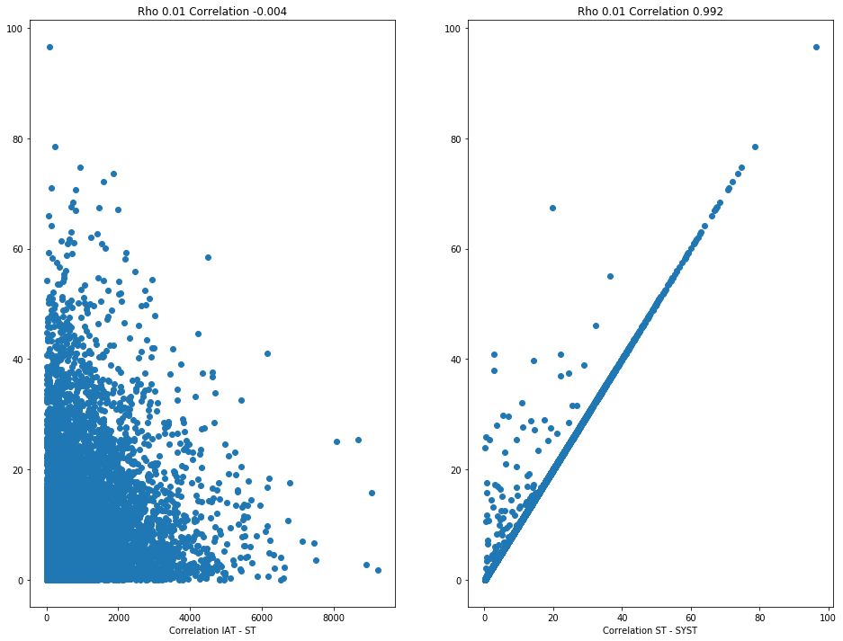

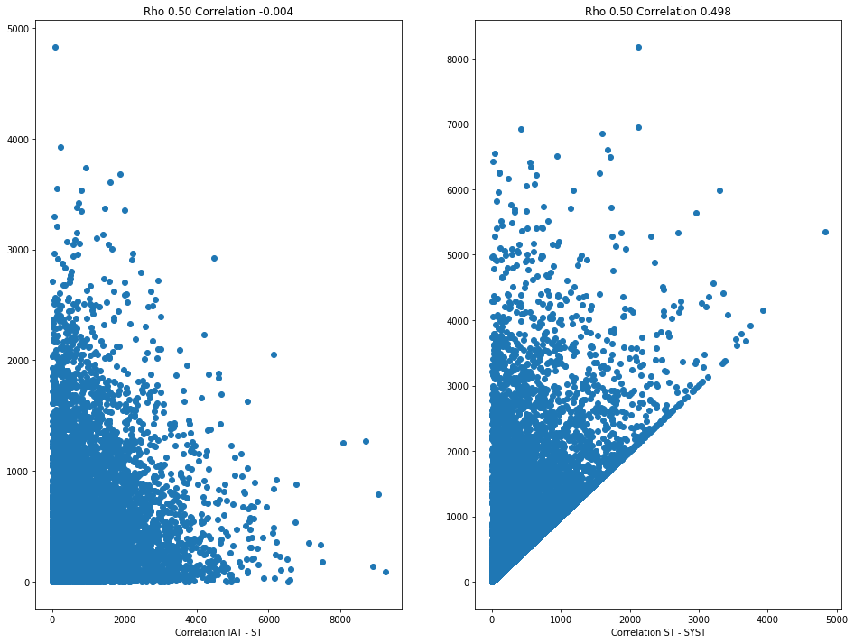

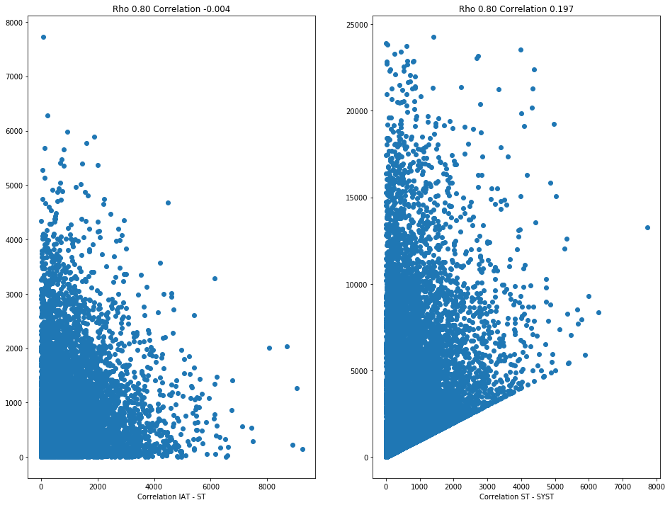

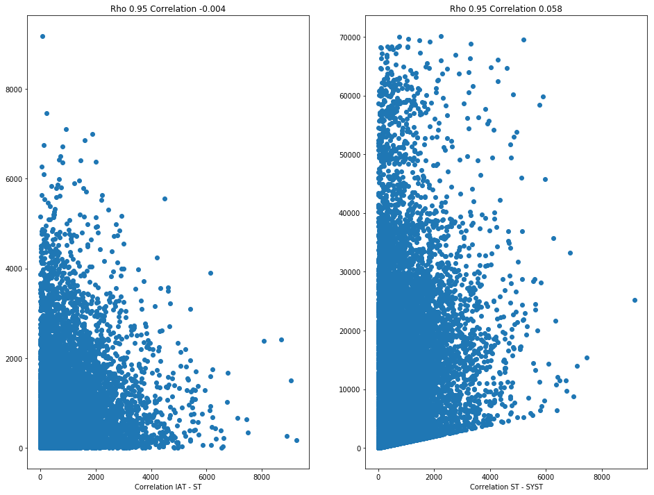

```python
part4_simstudy.task_4_3_2()
```

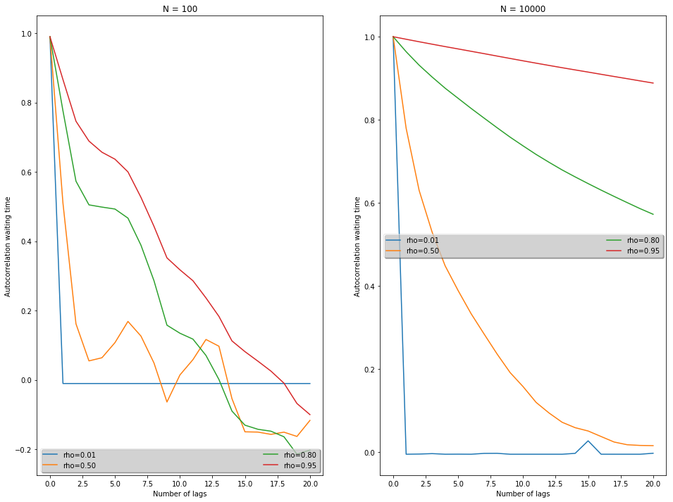

```python
part4_simstudy.task_4_3_3()
```

[output not shown]

## 4.4 Analysis and General Questions

### Task 4.4.2: Correlation Times in the DES

- **Correlation between IAT and waiting time of a packet:** Correlation between them is negative and not so high. So, if a packet arrives within short intervals, then it has to wait more.
- **Correlation between IAT and serving time of a packet:** It is very small and it can be considered as zero. This is actually expected result because both IAT and serving units are two different random processes so that there should be no correlation between them.
- **Correlation between IAT and system time (waiting time + serving time) of a packet:** System time is consists of waiting time and serving time, there is no correlation between IAT and serving time as I explained above but there is correlation between IAT and WT. Therefore, this will perform also negative correlation between IAT and system time. So, if IAT intervals are short then system time will be higher.
- **Correlation between serving time and system time of a packet:** As printed above, the correlation between ST and Syst. is high for low rho values and low for higher rho values.
- **Auto-correlation of waiting time with lags ranging from 1 to 20:** The auto-correlation of WT is depend on the RHO value, for larger rho values correlation is really high. For higher rho values, arrival rate will be higher so that packets most likely have to wait more time.

### Task 4.4.3: Visualization of Covariance/Correlation

- If there is no correlation, then the points in the scatter plot will be independent from each other. If there is a positive correlation(e.g. 0.99) then the points will be on the same line but skewed on the right. Also, If there is a negative correlation, than the shape of the graph skewed on the left. So, correlation affects the behaviour of dots in the scatter plots.

### Task 4.4.4: Auto Correlation

- For smaller N values(e.g.100), plots are faded rapidly because of the transient state. Small N is not enough to observe the behaviour of the system since it does not provide long simulation run.